# Statistical Learning Project2

# Hypothesis Testing

4a. Do charges of people who smoke differ significantly from the people who don't?

H0 : Charges of People who smoke = charges of People who don't smoke

H1 : Charges of People differ significantly between smoke and non smoking

H0 : smoke_grp['charges'].mean() = nosmoke_grp['charges'].mean()

H1 : smoke_grp['charges'].mean() != nosmoke_grp['charges'].mean()

alpha = 0.05

```python
smoke_grp=ins[ins['smoker']=='yes']
nosmoke_grp=ins[ins['smoker']=='no']
```

```python
ins.groupby("smoker")['charges'].describe()
```

| smoker | count | mean | std | min | 25% | 50% | 75% | max |
| --- | --- | --- | --- | --- | --- | --- | --- | --- |
| no | 1064.0 | 8434.268298 | 5993.781819 | 1121.8739 | 3986.438700 | 7345.40530 | 11362.887050 | 36910.60803 |
| yes | 274.0 | 32050.231832 | 11541.547176 | 12829.4551 | 20826.244213 | 34456.34845 | 41019.207275 | 63770.42801 |

```python
#predecessor check on data distribution
# 1. Tests for Homogeneity of variances ( optional )
stats.levene(smoke_grp['charges'], nosmoke_grp['charges'])
```

```
LeveneResult(statistic=332.6135162726081, pvalue=1.5593284881803726e-66)
```

```python
from scipy.stats import ttest_ind

ttest_ind(smoke_grp['charges'], nosmoke_grp['charges'])

#If p value is less than 0.05 then evidence of alternate and hence reject null.
```

```
Ttest_indResult(statistic=46.664921172723716, pvalue=8.271435842177219e-283)
```

```python
print('p value is very less than 0.05 and hence reject null hypothesis')
print('Charges of people differ significantly between smoking and non smoking based on t test')
```

```
p value is very less than 0.05 and hence reject null hypothesis
Charges of people differ significantly between smoking and non smoking based on t test
```

4b. Does bmi of males differ significantly from that of females?

H0: bmi of males = bmi of females

H1 : bmi of males differ significantly from that of females

```python
male_grp=ins[ins['sex']=='male']
female_grp=ins[ins['sex']=='female']

#1. Tests for Homogeneity of variances ( optional )
stats.levene(male_grp['bmi'], female_grp['bmi'])
```

```
LeveneResult(statistic=0.0039394029791134, pvalue=0.949963293424026)
```

```python
t,p=ttest_ind(male_grp['bmi'], female_grp['bmi'])
print(t,p)
```

```
1.696752635752224 0.08997637178984932
```

```python
print('p value %.5f'%(p))
print('p value is greater than 0.05 and hence failed to reject null hypothesis')
print('bmi of males does not differ significantly from bmi of females based on t test')
```

```
p value 0.08998
p value is greater than 0.05 and hence failed to reject null hypothesis
bmi of males does not differ significantly from bmi of females based on t test
```

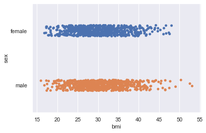

```python
sns.stripplot(ins['bmi'], ins['sex'])
```

4c. Is the proportion of smokers significantly different in different genders?

```python
# chi square test - testing relationship between categorical variables
#chisquare(ins)

contingency_table = pd.crosstab(
    ins['sex'],
    ins['smoker'],
    margins = True
)
contingency_table
```

| smoker sex | no | yes | All |
| --- | --- | --- | --- |
| female | 547 | 115 | 662 |
| male | 517 | 159 | 676 |
| All | 1064 | 274 | 1338 |

```python
chi2_stat, p_val, dof, ex = stats.chi2_contingency(contingency_table)
print("===Chi2 Stat===")
print(chi2_stat)
print("\n")
print("===Degrees of Freedom===")
print(dof)
print("\n")
print("===P-Value===")
print(p_val)
print("\n")
print("===Contingency Table===")
print(ex)
```

```
===Chi2 Stat===
7.765921028604452


===Degrees of Freedom===
4


===P-Value===
0.10053907554919742


===Contingency Table===
[[ 526.43348281  135.56651719  662.        ]
 [ 537.56651719  138.43348281  676.        ]
 [1064.          274.         1338.        ]]
```

```python
print('p value is not less than 0.05 and hence failed to reject null hypothesis')
print('proportion of smokers does not differ between genders')
```

```
p value is not less than 0.05 and hence failed to reject null hypothesis
proportion of smokers does not differ between genders
```

4d. Is the distribution of bmi across women with no children, one child and two children, the same ?

ANOVA test of bmi across groups of 0,1 and 2 children group

```python
ins['children']=ins['children'].astype('category')
print(ins.dtypes)
```

```
age            int64
sex           object
bmi          float64
children    category
smoker        object
region        object
charges      float64
dtype: object
```

```python
ins_women=ins[ins['sex']=='female' ]
#& ins['children']==0]
              #.isin(0,1,2)]
ins_women
```

|  | age | sex | bmi | children | smoker | region | charges |
| --- | --- | --- | --- | --- | --- | --- | --- |
| 0 | 19 | female | 27.90 | 0 | yes | southwest | 16884.92400 |
| 5 | 31 | female | 25.74 | 0 | no | southeast | 3756.62160 |
| 6 | 46 | female | 33.44 | 1 | no | southeast | 8240.58960 |
| 7 | 37 | female | 27.74 | 3 | no | northwest | 7281.50560 |
| 9 | 60 | female | 25.84 | 0 | no | northwest | 28923.13692 |
| ... | ... | ... | ... | ... | ... | ... | ... |
| 1332 | 52 | female | 44.70 | 3 | no | southwest | 11411.68500 |
| 1334 | 18 | female | 31.92 | 0 | no | northeast | 2205.98080 |
| 1335 | 18 | female | 36.85 | 0 | no | southeast | 1629.83350 |
| 1336 | 21 | female | 25.80 | 0 | no | southwest | 2007.94500 |
| 1337 | 61 | female | 29.07 | 0 | yes | northwest | 29141.36030 |

662 rows × 7 columns

```python
stats.f_oneway(ins_women['bmi'][ins_women['children'] == 0], ins_women['bmi'][ins_women['children'] == 1],ins_women['bmi'][ins_women['children'] == 2])
```

```
F_onewayResult(statistic=0.3344720147757968, pvalue=0.7158579926754841)
```

```python
print('p value is > 0.05 and hence failed to reject null hypothesis')
print('There is no significant difference in bmi across women having 0 1 and 2 children')
```

```
p value is > 0.05 and hence failed to reject null hypothesis
There is no significant difference in bmi across women having 0 1 and 2 children
```